# Handwritten Alphabet Recognition using Neural Networks

## Adam Optimizer

Adam is a replacement optimization algorithm for **stochastic gradient descent**.

It combines the best properties of the *AdaGrad* and *RMSProp* algorithms to provide an optimization algorithm that can handle **sparse gradients on noisy problems**.

**Momentum 0.5**

```python
model.compile(optimizer=SGD(learning_rate=LEARNING_RATE, momentum=0.5), loss='categorical_crossentropy', metrics=['accuracy', Precision(), Recall(), f1_score])
```

```python
history = model.fit(X_train, y_train, epochs=EPOCHS, batch_size=BATCH_SIZE)
```

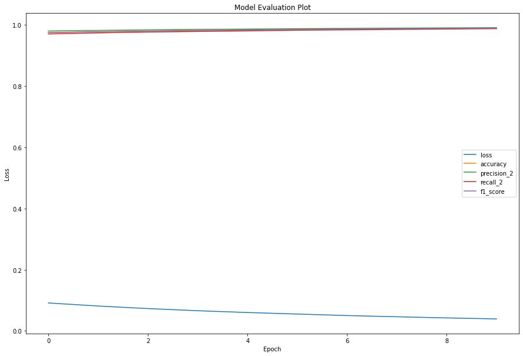

```python
evaluation_plot(history)
```

**Momentum 0.9**

```python
model.compile(optimizer=SGD(learning_rate=LEARNING_RATE, momentum=0.9), loss='categorical_crossentropy', metrics=['accuracy', Precision(), Recall(), f1_score])
```

```python
history = model.fit(X_train, y_train, epochs=EPOCHS, batch_size=BATCH_SIZE)
```

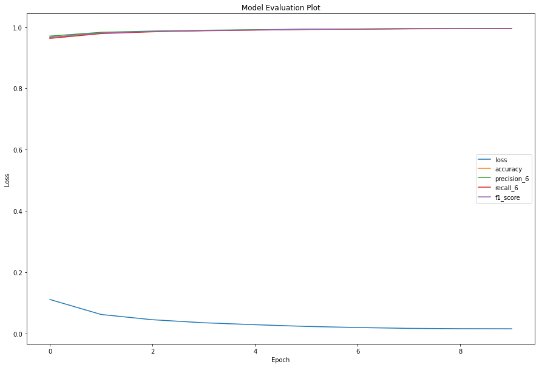

```python
evaluation_plot(history)
```

**Momentum 0.98**

```python
model.compile(optimizer=SGD(learning_rate=LEARNING_RATE, momentum=0.98), loss='categorical_crossentropy', metrics=['accuracy', Precision(), Recall(), f1_score])
```

```python
history = model.fit(X_train, y_train, epochs=EPOCHS, batch_size=BATCH_SIZE)
```

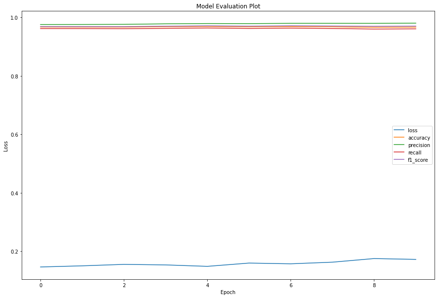

```python
evaluation_plot(history)
```

Momentum was designed to speed up learning in directions of low curvature, without becoming unstable in directions of high curvature. In deep learning, most practitioners set the value of momentum to **0.9** without attempting to further tune this hyperparameter

As you can see here, increasing the momentum won't always make the model better.

**Adam Optimizer**

```python
model.compile(optimizer=Adam(learning_rate=0.001), loss='categorical_crossentropy', metrics=['accuracy', Precision(), Recall(), f1_score])
```

```python
history = model.fit(X_train, y_train, epochs=EPOCHS, batch_size=BATCH_SIZE)
```

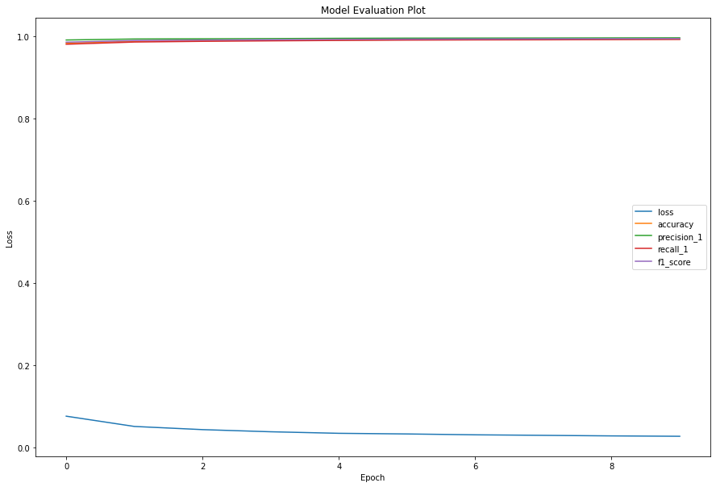

```python
evaluation_plot(history)
```

# Epochs

## What is epochs?

The number of epochs is a hyperparameter that defines the number times that the learning algorithm will work through the entire training dataset.

## Why do we use epochs?

We want to get good performance on non-training data and usuallythat takes more than one pass over the training data

## Can we use 1 epoch?

It is ok to use only one epoch if you have so many examples and they are similar. If you train it long enough, it could reach 100% accuracy on a specific task. The conclusion is that only running 1 epoch is fine, as long as the examples are sampled from the **same distribution**.

## Is more epoch, better?

As the number of epochs increases, more number of times the weight are changed in the neural network and the curve goes from underfitting to optimal to overfitting curve. Therefore one of the epochs critical issues is that it might **overfit**.

## How to prevent epochs leading to overfitting?

Some ways to prevent overfitting caused by epochs:

- Using Dropouts
- Early Stopping
- Using Regularization

```python
model.compile(optimizer=Adam(learning_rate=0.001), loss='categorical_crossentropy', metrics=['accuracy', Precision(), Recall(), f1_score])
```

```python
history = model.fit(X_train, y_train, epochs=20, batch_size=BATCH_SIZE)
```

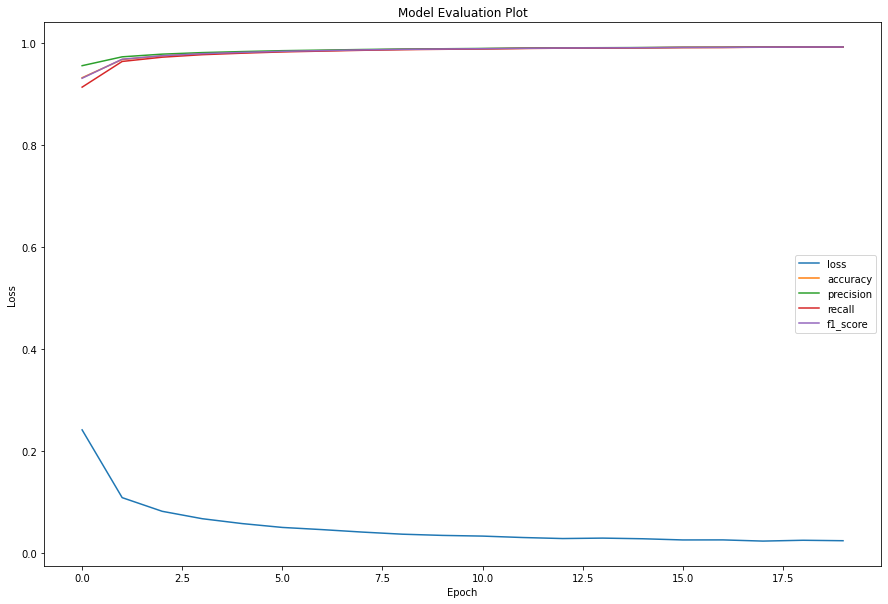

```python
evaluation_plot(history)
```

# Loss Function

## What is loss function?

The loss function in a neural network quantifies the difference between the expected outcome and the outcome produced by the machine learning model.

From the loss function, we can derive the gradients which are used to update the weights

## Cross-Entropy

Cross-entropy-based loss functions are commonly used in classification scenarios

### Categorical Cross-Entropy

The categorical cross-entropy is applied in multiclass classification scenarios

## Mean-Squared-Error

Mean squared error (MSE) is the most commonly used loss function for regression and is calculated by taking the difference between `y` and our prediction, then square those values.

## Two reasons that using MSE for classification is not a good choice:

- By using MSE, we assume that the underlying data has been generated from a **normal distribution**, While in reality, a dataset that can be classified into two categories which is not from a normal distribution but a **Bernoulli distribution**.
- If a binary classification model is trained with MSE Cost function, it is not guaranteed to minimize the Cost function.

## When is it a good-practice to use MSE?

Using MSE in regression is pretty popular and The Mean Squared Error is used as a default metric for evaluation of the performance of most regression algorithms.

```python
model.compile(optimizer=Adam(learning_rate=0.001), loss='mean_squared_error', metrics=['accuracy', Precision(), Recall(), f1_score])
```

```python
history = model.fit(X_train, y_train, epochs=EPOCHS, batch_size=BATCH_SIZE)
```

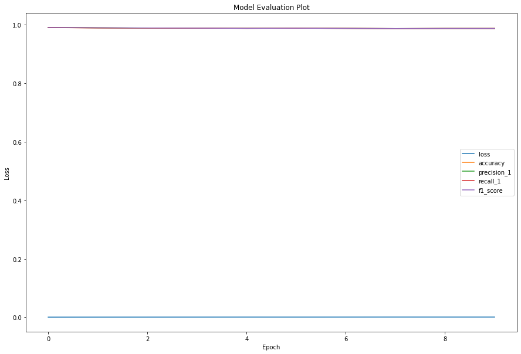

```python
evaluation_plot(history)
```